# Tidymodels

## 1. Introduction

Tidymodels: https://www.tmwr.org/.

Models are mathematical tools that can describe a system and capture relationships in the data given to them. The utility of a model hinges on its ability to be reductive.

### 1.1. Types of models

#### Descriptive models

The purpose of a descriptive model is to describe or illustrate characteristics of some data. The analysis might have no other purpose than to visually emphasize some trend or artifact in the data. An example can be a LOESS (locally estimated smoothing model) model, that consists on a smooth and flexible regression model. This model is used to discover potential ways to represent a variable.

#### Inferential models

The goal of an inferential model is to produce a decision for a research question or to test a specific hypothesis. It aims to make some statement of truth regarding a predefined conjecture or idea. In many cases, a qualitative statement is produced (e.g, a difference was “statistically significant”).

For example, in a clinical trial, the goal might be to provide confirmation that a new therapy does a better job in prolonging life than an alternative, like an existing therapy or no treatment. If the clinical endpoint was related to survival of a patient, the null hypothesis might be that the two therapeutic groups have equal median survival times with the alternative hypothesis being that the new therapy has higher median survival. If this trial were evaluated using the traditional null hypothesis significance testing, a p-value would be produced using some predefined methodology. Small values of the p-value indicate that there is evidence that the new therapy does help patients live longer. If not, the trial would conclude that there is a failure to show such a difference, which could be due to a number of reasons.

Inferential techniques typically produce some type of probabilistic output, such as a p-value, confidence interval, or posterior probability. There tends to be a delayed feedback loop in understanding how well the data matches the assumptions. In the clinical trial example, if statistical significance indicate that the new therapy should be available for patients to use, it still may be years before it is used in the field and enough data are generated for an independent assessment of whether the original statistical analysis led to the appropriate decision.

#### Predictive models

They model data to produce the most accurate prediction possible for new data. The primary goal is that the predicted values have the highest possible fidelity to the true value of the new data. A simple example would be for a book buyer to predict how many copies of a particular book should be shipped to their store for the next month. For this type of model, the problem type is one of estimation rather than inference.

### 1.2 Terminology

Many models can be categorised as being supervised or unsupervised. Unsupervised models are those that learn patterns, clusters or other characteristics of the data but lack an outcome variable. PCA, cluster or autoencoders are examples of unsupervised models.They are used to understand relationships between variables or sets of variables without an explicit relationship between variables and an outcome. Supervised models are those that have an outcome variable. Within supervised models, there are two main sub-categories: Regression predicts a numeric outcome. Classification predicts an outcome that it is an ordered or unordered set of qualitative values.

The modeling workflow usually starts with Exploratory Data Analysis (EDA), then continues with initial feature engineering, initial models and model tuning, model evaluation, more feature engineering, refined models and model tuning, and lastly, final model evaluation.

EDA consists of numerical analysis and visualization where different discoveries lead to more questions and “side-quests” to gain more understanding.

Feature engineering contains specific model terms that make easier to accurately model the observed data. This can include complex methodologies such as PCA, or simple features (using the ratio of two predictors).

Model tuning and selection: some models require parameter tuning where some structural parameters are required to be specific or optimized.

Model evaluation: Assess the model’s performance metrics, examine residual plots and conduct other EDA-like analyses to understand how well the models work.

Refer to the table of cases used in https://www.tmwr.org/software-modeling.html#predictive-models

Chapters 2 and 3 not covered here.

## 4. Ames housing data

```r
library(modeldata)
library(ggplot2)
library(tidyverse)
data(ames)
dim(ames)
```

```
## [1] 2930   74
```

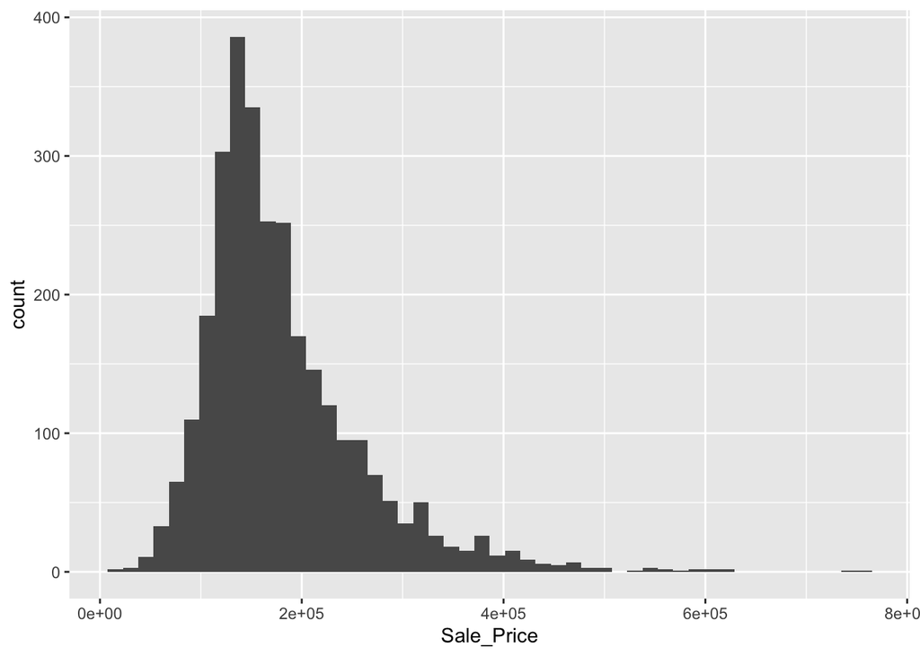

```r
# Exploring variables
ggplot(ames,aes(Sale_Price)) + geom_histogram(bins=50)
```

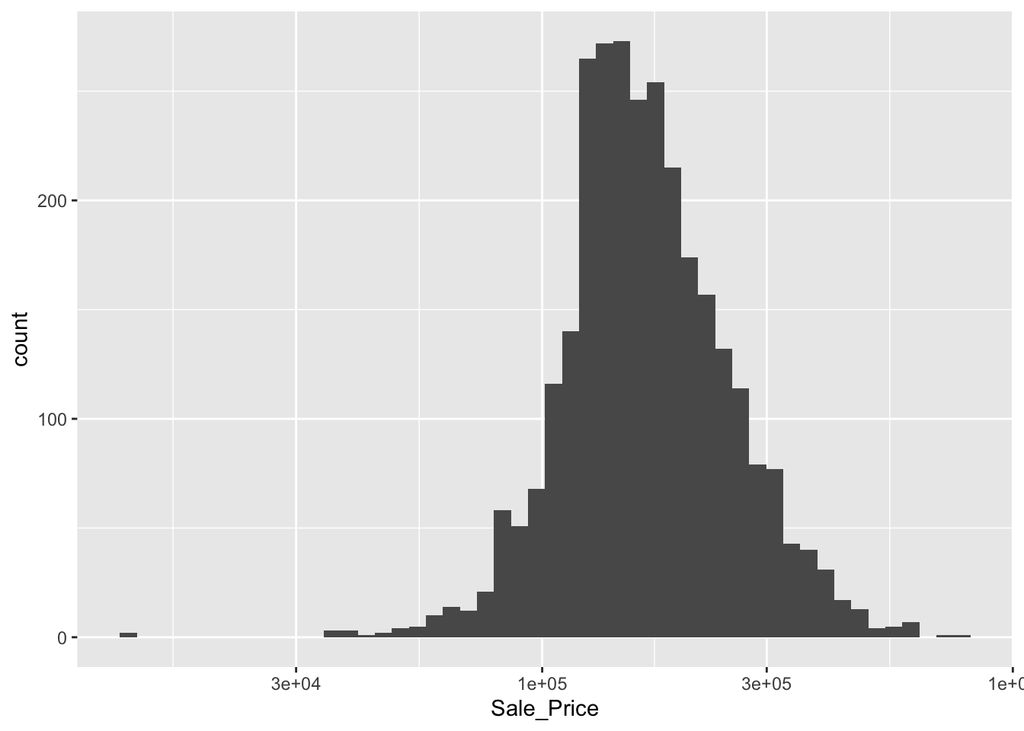

```r
ggplot(ames,aes(Sale_Price)) + geom_histogram(bins=50) + scale_x_log10()
```

```r
# Transform sale price into log
ames = ames %>%
  mutate(Sale_Price = log10(Sale_Price))
```

## 5. Spending our data

The idea of data spending is an important first consideration when modeling, especially as it relates to empirical validation. When there are copious amounts of data available, a smart strategy is to allocate specific subsets of data for different tasks, as opposed to allocating the largest possible amount to the model parameter estimation only.

### 5.1 Common methods for splitting data

The primary approach for empirical model validation is to split the existing pool of data into two distinct sets. Some observations are used to develop and optimize the model. This training set is usually the majority of the data. These data are a sandbox for model building where different models can be fit, feature engineering strategies are investigated. The other portion of the observations are placed into the test set. This is held in reserve until one or two models are chosen as the methods that are mostly likely to succeed. The test set is then used as the final arbiter to determine the efficacy of the model. It is critical to only look at the test set once, otherwise it becomes part of the modeling process.

```r
library(rsample)

# set random seed
set.seed(123)

# split train / test
ames_split = initial_split(ames,prob=0.80)
ames_split
```

```
## <Analysis/Assess/Total>
## <2198/732/2930>
```

```r
ames_train = training(ames_split)
ames_test = testing(ames_split)
dim(ames_train)
```

```
## [1] 2198   74
```

When splitting randomly, we might find class imbalance, one class occurs much less frequently than another. To avoid this, stratified sampling can be used. The train/test is conducted separately within each class and then subsamples are combined into the overall training and test set. For regression problems, the outcome data can be artificially binned into quartiles and then stratified sampling conducted four separate times.This is an effective method for keeping the distributions of the outcome similar between training and test set.

```r
set.seed(123)
ames_split = initial_split(ames,prob=0.8,strata=Sale_Price)
ames_train = training(ames_split)
ames_test = testing(ames_split)
dim(ames_train)
```

```
## [1] 2199   74
```

### 5.2 What proportion should be used?

The amount of data that should be allocated when splitting the data is highly dependent on the context of the problem at hand. Too much data in the training set lowers the quality of the performance estimates. Conversely, too much data in the test set handicaps the model’s ability to find appropriate parameter estimates.Test set should be avoided only when the data are pathologically small.

### 5.3 What about a validation set?

How can we tell what is best if we don’t measure performance until the test set?. It is common to hear about validation sets as an answer to this question, especially in the neural network and deep learning literature. The validation set was originally defined in the early days of neural networks when researchers realized that measuring performance by re-predicting the training set samples led to results that were overly optimistic. This led to models that overfit, models that performed very well on the training set but poorly in the test set. To combat this issue, a small validation set of data were held back and used to measure performance as the network was trained. Once the validation set error rate began to rise, the training would be halted. The validation set was a means to get a rough sense of how well the model performed prior to the test set.

### 5.4 Multi-level data

With the Ames housing data, a property is considered to be the independent experimental unit. It is safe to assume that, statistically, the data from a property are independent. For other applications, that is not always the case.

- For longitudinal data, the same independent experimental unit can be measured over multiple time points. An example would be a human subject in a medical trial.
- A batch of manufactured product might also be considered the independent experimental unit. In repeated measures designs, replicate data points from a batch are collected.

In these situations, the data set will have multiple rows per experimental unit. Simple resampling across rows would lead to some data within an experimental unit being in the training set and others in the test set. Data splitting should occur at the independent experimental unit level of the data. For example, to produce an 80/20 split of the data, 80% of the experimental units should be allocated for the training set.

## 6. Feature engineering with recipes

Feature engineering encompasses activities that reformat predictor values to make them easier for a model to use effectively. This includes transformations and encodings of the data to best represent their important characteristics. Imagine that you have two predictors in a data set that can be more effectively represented in your model of interest as a ratio; creating a new predictor from the ratio of the original two is a simple example of feature engineering.

Take the location of a house in Ames as a more involved example. There are a variety of ways that this spatial information can be exposed to a model, including neighborhood (a qualitative measure), longitude/latitude, distance to the nearest school or Iowa State University, and so on.

Feature engineering and data preprocessing can also involve reformatting required by the model. Some models use geometric distance metrics and, consequently, numeric predictors should be centered and scaled so that they are all in the same units.

### 6.1 A simple recipe for the Ames housing data

In this section, we will focus on a small subset of the predictors available in the Ames housing data:

- The neighborhood (qualitative, with 29 neighborhoods in the training set)
- The general living area (continuous, named Gr_Liv_Area)
- The year built (Year_Built)
- The type of building (Bldg_Type with values OneFam (n=1,814), TwoFmCon (n=45), Duplex (n=76), Twnhs (n=76), and TwnhsE (n=188))

```r
library(tidymodels) # Includes the recipes package
simple_ames <-
  recipe(Sale_Price ~ Neighborhood + Gr_Liv_Area + Year_Built + Bldg_Type,
         data = ames_train) %>%
  step_log(Gr_Liv_Area, base = 10) %>%
  step_dummy(all_nominal())
simple_ames
```

```
## Data Recipe
##
## Inputs:
##
##       role #variables
##    outcome          1
##  predictor          4
##
## Operations:
##
## Log transformation on Gr_Liv_Area
## Dummy variables from all_nominal()
```

### 6.2 Using recipes

When invoking the recipe() function, the steps are not estimated or executed in any way. The second phase for using a recipe is to estimate any quantities required by the steps using the prep() function. For example, we can use step_normalize() to center and scale any predictors selected in the step. When we call prep(recipe, training), this function estimates the required means and standard deviations from the data in the training argument. The transformations specified by each step are also sequentially executed on the data set. Again using normalization as the example, the means and variances are estimated and then used to standardize the columns.

```r
simple_ames <- prep(simple_ames, training = ames_train)
simple_ames
```

```
## Data Recipe
##
## Inputs:
##
##       role #variables
##    outcome          1
##  predictor          4
##
## Training data contained 2199 data points and no missing data.
##
## Operations:
##
## Log transformation on Gr_Liv_Area [trained]
## Dummy variables from Neighborhood, Bldg_Type [trained]
```

The third phase of recipe usage is to apply the preprocessing operations to a data set using the bake() function. The bake() function can apply the recipe to any data set. To use the test set, the syntax would be:

```r
test_ex <- bake(simple_ames, new_data = ames_test)
names(test_ex) %>% head()
```

```
## [1] "Gr_Liv_Area"                "Year_Built"
## [3] "Sale_Price"                 "Neighborhood_College_Creek"
## [5] "Neighborhood_Old_Town"      "Neighborhood_Edwards"
```

The bake() function can also take selectors so that, if we only wanted the neighborhood results, we could use:

```r
bake(simple_ames, ames_test, starts_with("Neighborhood_"))
```

```
## # A tibble: 731 x 28
##    Neighborhood_Co… Neighborhood_Ol… Neighborhood_Ed… Neighborhood_So…
##               <dbl>            <dbl>            <dbl>            <dbl>
##  1                0                0                0                0
##  2                0                0                0                0
##  3                0                0                0                0
##  4                0                0                0                0
##  5                0                0                0                0
##  6                0                0                0                0
##  7                0                0                0                0
##  8                0                0                0                0
##  9                0                0                0                0
## 10                0                0                0                0
## # … with 721 more rows, and 24 more variables:
## #   Neighborhood_Northridge_Heights <dbl>, Neighborhood_Gilbert <dbl>,
## #   Neighborhood_Sawyer <dbl>, Neighborhood_Northwest_Ames <dbl>,
## #   Neighborhood_Sawyer_West <dbl>, Neighborhood_Mitchell <dbl>,
## #   Neighborhood_Brookside <dbl>, Neighborhood_Crawford <dbl>,
## #   Neighborhood_Iowa_DOT_and_Rail_Road <dbl>, Neighborhood_Timberland <dbl>,
## #   Neighborhood_Northridge <dbl>, Neighborhood_Stone_Brook <dbl>,
## #   Neighborhood_South_and_West_of_Iowa_State_University <dbl>,
## #   Neighborhood_Clear_Creek <dbl>, Neighborhood_Meadow_Village <dbl>,
## #   Neighborhood_Briardale <dbl>, Neighborhood_Bloomington_Heights <dbl>,
## #   Neighborhood_Veenker <dbl>, Neighborhood_Northpark_Villa <dbl>,
## #   Neighborhood_Blueste <dbl>, Neighborhood_Greens <dbl>,
## #   Neighborhood_Green_Hills <dbl>, Neighborhood_Landmark <dbl>,
## #   Neighborhood_Hayden_Lake <dbl>
```

Using a recipe there is a three phase process: recipe(): defines the pre-processing prep(): calculates statistics form the training set bake(): applies the preprocessing to data sets

### 6.3 Encoding qualitative data in a numeric format

One of the most common feature engineering tasks is transforming nominal or qualitative data (factors or characters) so that they can be encoded or represented numerically. Sometimes we can alter the factor levels of a qualitative column in helpful ways prior to such a transformation. For example, step_unknown() can be used to change missing values to a dedicated factor level. Similarly, if we anticipate that a new factor level may be encountered in future data, step_novel() can allot a new level for this purpose.

Additionally, step_other() can be used to analyze the frequencies of the factor levels in the training set and convert infrequently occurring values to a catch-all level of “other”, with a specific threshold that can be specified.

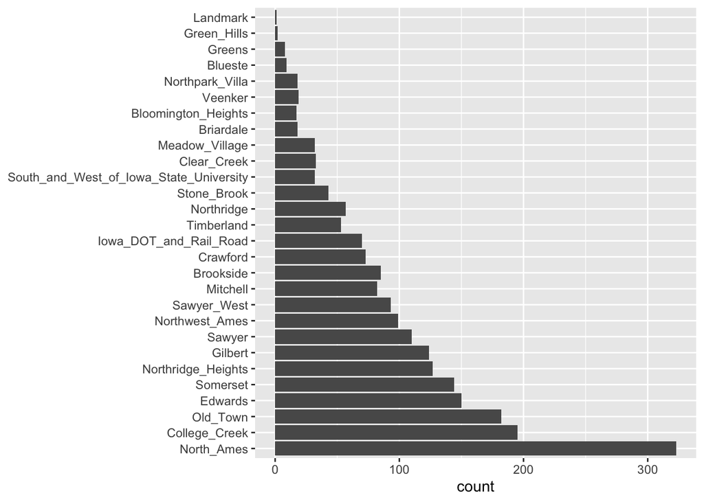

```r
ggplot(ames_train, aes(y = Neighborhood)) +
  geom_bar() +
  labs(y = NULL)
```

```r
simple_ames <-
  recipe(Sale_Price ~ Neighborhood + Gr_Liv_Area + Year_Built + Bldg_Type,
         data = ames_train) %>%
  step_log(Gr_Liv_Area, base = 10) %>%
  step_other(Neighborhood, threshold = 0.01) %>%
  step_dummy(all_nominal())
```

There are a few strategies for converting a factor predictor to a numeric format. The most common method is to create “dummy” or indicator variables.

Another method that is useful when there are a large number of categories is called effect or likelihood encodings. This method replaces the original data with a single numeric column that measures the effect of those data. For example, for the neighborhood predictor, the mean sale price is computed for each neighborhood and these means are substituted for the original data values. This can be effective but should be used with care.

### 6.4 Interaction terms

Interaction effects involve two or more predictors. Such an effect occurs when one predictor has an effect on the outcome that is contingent on one or more other predictors. For example, if you were trying to predict your morning commute time, two potential predictors could be the amount of traffic and the time of day. However, the relationship between commute time and the amount of traffic is different for different times of day. In this case, you could add an interaction term between the two predictors to the model along with the original two predictors (which are called the “main effects”). Numerically, an interaction term between predictors is encoded as their product.

Interactions are only defined in terms of their effect on the outcome and can be combinations of different types of data (e.g., numeric, categorical, etc).

After exploring the Ames training set, we might find that the regression slopes for the general living area differ for different building types:

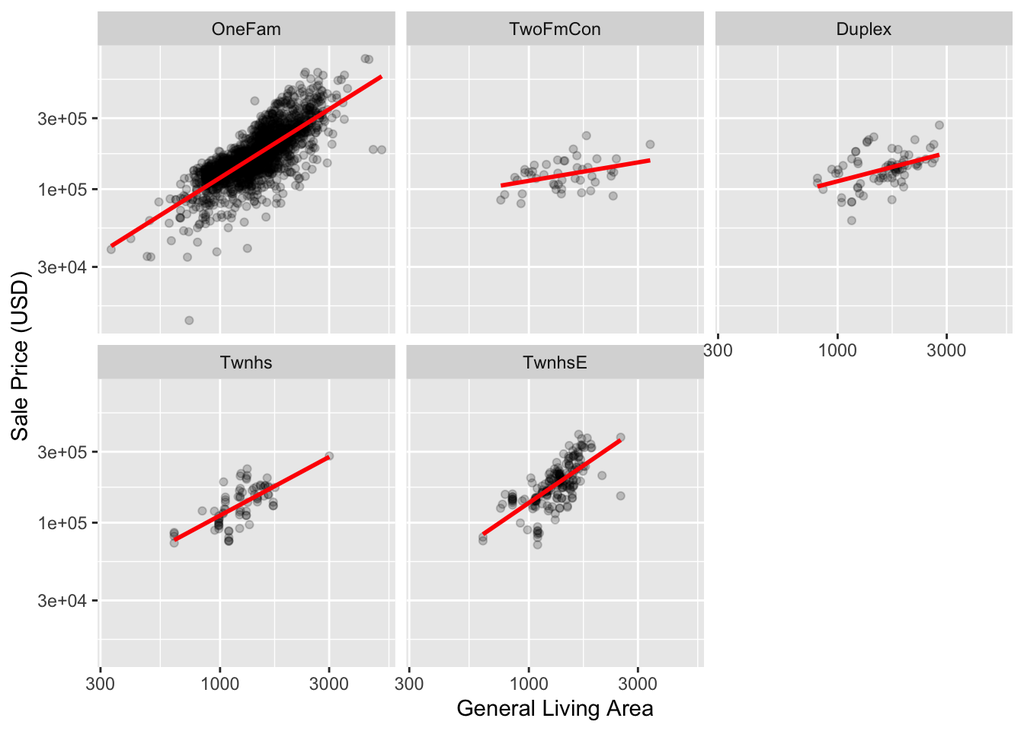

```r
ggplot(ames_train, aes(x = Gr_Liv_Area, y = 10^Sale_Price)) +
  geom_point(alpha = .2) +
  facet_wrap(~ Bldg_Type) +
  geom_smooth(method = lm, formula = y ~ x, se = FALSE, col = "red") +
  scale_x_log10() +
  scale_y_log10() +
  labs(x = "General Living Area", y = "Sale Price (USD)")
```

How are interactions specified in a recipe?

```r
Sale_Price ~ Neighborhood + log10(Gr_Liv_Area) + Bldg_Type + log10(Gr_Liv_Area):Bldg_Type
```

```
## Sale_Price ~ Neighborhood + log10(Gr_Liv_Area) + Bldg_Type +
##     log10(Gr_Liv_Area):Bldg_Type
```

```r
# or
Sale_Price ~ Neighborhood + log10(Gr_Liv_Area) * Bldg_Type
```

```
## Sale_Price ~ Neighborhood + log10(Gr_Liv_Area) * Bldg_Type
```

where * expands those columns to the main effects and interaction term. Again, the formula method does many things simultaneously and understands that a factor variable (such as Bldg_Type) should be expanded into dummy variables first and that the interaction should involve all of the resulting binary columns

Recipes are more explicit and sequential, and give you more control. With the current recipe, step_dummy() has already created dummy variables. How would we combine these for an interaction? The additional step would look like step_interact(~ interaction terms) where the terms on the right-hand side of the tilde are the interactions. These can include selectors, so it would be appropriate to use:

```r
simple_ames <-
  recipe(Sale_Price ~ Neighborhood + Gr_Liv_Area + Year_Built + Bldg_Type,
         data = ames_train) %>%
  step_log(Gr_Liv_Area, base = 10) %>%
  step_other(Neighborhood, threshold = 0.01) %>%
  step_dummy(all_nominal()) %>%
  # Gr_Liv_Area is on the log scale from a previous step
  step_interact( ~ Gr_Liv_Area:starts_with("Bldg_Type_") )
```

### 6.6 Other examples of recipe steps

#### Spline functions

When a predictor has a nonlinear relationship with the outcome, some types of predictive models can adaptively approximate this relationship during training. However, simpler is usually better and it is not uncommon to try to use a simple model, such as a linear fit, and add in specific non-linear features for predictors that may need them. One common method for doing this is to use spline functions to represent the data. Splines replace the existing numeric predictor with a set of columns that allow a model to emulate a flexible, non-linear relationship.

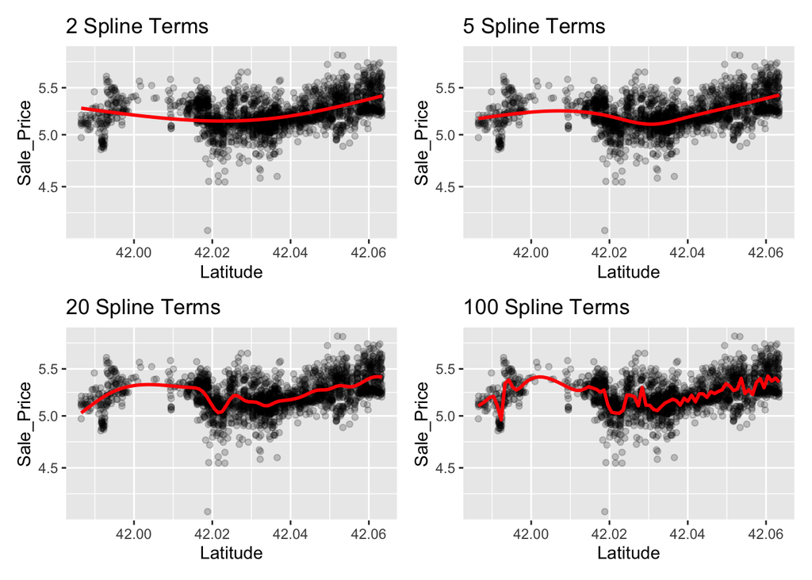

```r
library(patchwork)
library(splines)

plot_smoother <- function(deg_free) {
  ggplot(ames_train, aes(x = Latitude, y = Sale_Price)) +
    geom_point(alpha = .2) +
    scale_y_log10() +
    geom_smooth(
      method = lm,
      formula = y ~ ns(x, df = deg_free),
      col = "red",
      se = FALSE
    ) +
    ggtitle(paste(deg_free, "Spline Terms"))
}

( plot_smoother(2) + plot_smoother(5) ) / ( plot_smoother(20) + plot_smoother(100) )
```

Some panels clearly fit poorly; two terms under-fit the data while 100 terms over-fit. The panels with five and 20 terms seem like reasonably smooth fits that catch the main patterns of the data. This indicates that the proper amount of “non-linear-ness” matters. The number of spline terms could then be considered a tuning parameter for this model.

#### Feature extraction

Another common method for representing multiple features at once is called feature extraction. Most of these techniques create new features from the predictors that capture the information in the broader set as a whole. For example, principal component analysis (PCA) tries to extract as much of the original information in the predictor set as possible using a smaller number of features. PCA is a linear extraction method, meaning that each new feature is a linear combination of the original predictors. One nice aspect of PCA is that each of the new features, called the principal components or PCA scores, are uncorrelated with one another.

In the Ames data, there are several predictors that measure size of the property, such as the total basement size (Total_Bsmt_SF), size of the first floor (First_Flr_SF), the general living area (Gr_Liv_Area), and so on. PCA might be an option to represent these potentially redundant variables as a smaller feature set. Apart from the general living area, these predictors have the suffix SF in their names (for square feet) so a recipe step for PCA might look like:

```r
# Use a regular expression to capture house size predictors:
  #step_pca(matches("(SF$)|(Gr_Liv)"))
```

Note that all of these columns are measured in square feet. PCA assumes that all of the predictors are on the same scale. That’s true in this case, but often this step can be preceded by step_normalize(), which will center and scale each column.

#### Row sampling steps

Recipe steps can affect the rows of a data set as well. For example, the previously mentioned subsampling technique for class imbalances will change the data being given to the model. There are several possible approaches to try:

- Downsampling the data keeps the minority class and takes a random sample of the majority class so that class frequencies are balanced.
- Upsampling replicates samples from the minority class to balance the classes. Some techniques do this by synthesizing new samples that resemble the minority class data while other methods simply add the same minority samples repeatedly.

themis package has recipe steps that can be used for this purpose. For simple down-sampling, we would use:

```r
#step_downsample(outcome_column_name)
```

There are other step functions that are row-based as well: step_filter(), step_sample(), step_slice(), and step_arrange(). In almost all uses of these steps, the skip argument should be set to TRUE.

## 7. Fitting models with parsnip

The parsnip package provides a fluent and standardized interface for a variety of different models.

### 7.1. Create a model

Once the data have been encoded in a format ready for a modeling algorithm, such as a numeric matrix, they can be used in the model building process.

Suppose that a linear regression model was our initial choice for the model. There are a variety of methods that can be used to estimate the model parameters:

- Ordinary linear regression uses the traditional method of least squares to solve for the model parameters.
- Regularized linear regression adds a penalty to the least squares method to encourage simplicity by removing predictors and/or shrinking their coefficients towards zero. This can be executed using Bayesian or non-Bayesian techniques

For tidymodels, the approach to specifying a model is intended to be more unified:

1. Specify the type of model based on its mathematical structure (e.g., linear regression, random forest, K-nearest neighbors, etc).
2. Specify the engine for fitting the model. Most often this reflects the software package that should be used.
3. When required, declare the mode of the model. The mode reflects the type of prediction outcome. For numeric outcomes, the mode is regression; for qualitative outcomes, it is classification10. If a model can only create one type of model, such as linear regression, the mode is already set.

Let’s walk through how to predict the sale price of houses in the Ames data as a function of only longitude and latitude.

```r
lm_model <-
  linear_reg() %>%
  set_engine("lm")

lm_form_fit <-
  lm_model %>%
  # Recall that Sale_Price has been pre-logged
  fit(Sale_Price ~ Longitude + Latitude, data = ames_train)

lm_xy_fit <-
  lm_model %>%
  fit_xy(
    x = ames_train %>% select(Longitude, Latitude),
    y = ames_train %>% pull(Sale_Price)
    )

lm_form_fit
```

```
## parsnip model object
##
## Fit time:  2ms
##
## Call:
## stats::lm(formula = Sale_Price ~ Longitude + Latitude, data = data)
##
## Coefficients:
## (Intercept)    Longitude     Latitude
##    -316.368       -2.083        3.010
```

```r
lm_xy_fit
```

```
## parsnip model object
##
## Fit time:  2ms
##
## Call:
## stats::lm(formula = ..y ~ ., data = data)
##
## Coefficients:
## (Intercept)    Longitude     Latitude
##    -316.368       -2.083        3.010
```

Modeling functions in parsnip separate model arguments into two categories:

- Main arguments are more commonly used and tend to be available across engines.
- Engine arguments are either specific to a particular engine or used more rarely.

```r
rand_forest(trees = 1000, min_n = 5) %>%
  set_engine("ranger", verbose = TRUE) %>%
  set_mode("regression")
```

```
## Random Forest Model Specification (regression)
##
## Main Arguments:
##   trees = 1000
##   min_n = 5
##
## Engine-Specific Arguments:
##   verbose = TRUE
##
## Computational engine: ranger
```

### 7.2 Use the model results

Once the model is created and fit, we can use the results in a variety of ways; we might want to plot, print, or otherwise examine the model output. Several quantities are stored in a parsnip model object, including the fitted model. This can be found in an element called fit, which can be returned using the purrr::pluck() function:

```r
lm_form_fit %>% pluck("fit")
```

```
##
## Call:
## stats::lm(formula = Sale_Price ~ Longitude + Latitude, data = data)
##
## Coefficients:
## (Intercept)    Longitude     Latitude
##    -316.368       -2.083        3.010
```

Normal methods can be applied to this object, such as printing, plotting, and so on:

```r
lm_form_fit %>% pluck("fit") %>% vcov()
```

```
##             (Intercept)     Longitude      Latitude
## (Intercept)  221.762700  1.6944059879 -1.5009965142
## Longitude      1.694406  0.0177914308 -0.0006748145
## Latitude      -1.500997 -0.0006748145  0.0342053401
```

One issue with some existing methods in base R is that the results are stored in a manner that may not be the most useful. For example, the summary() method for lm objects can be used to print the results of the model fit, including a table with parameter values, their uncertainty estimates, and p-values. These particular results can also be saved:

```r
model_res <-
  lm_form_fit %>%
  pluck("fit") %>%
  summary()

# The model coefficient table is accessible via the `coef` method.
param_est <- coef(model_res)
class(param_est)
```

```
## [1] "matrix" "array"
```

```r
param_est
```

```
##                Estimate Std. Error   t value     Pr(>|t|)
## (Intercept) -316.367858 14.8916990 -21.24458 3.040399e-91
## Longitude     -2.083107  0.1333845 -15.61731 3.214884e-52
## Latitude       3.009920  0.1849469  16.27451 2.584812e-56
```

### 7.3 Make predictions

Another area where parsnip diverges from conventional R modeling functions is the format of values returned from predict(). For predictions, parsnip always conforms to the following rules:

- The results are always a tibble.
- The column names of the tibble are always predictable.
- There are always as many rows in the tibble as there are in the input data set.

```r
ames_test_small <- ames_test %>% slice(1:5)
predict(lm_form_fit, new_data = ames_test_small)
```

```
## # A tibble: 5 x 1
##   .pred
##   <dbl>
## 1  5.22
## 2  5.29
## 3  5.28
## 4  5.26
## 5  5.24
```

The row order of the predictions are always the same as the original data.

These three rules make it easier to merge predictions with the original data:

```r
ames_test_small %>%
  select(Sale_Price) %>%
  bind_cols(predict(lm_form_fit, ames_test_small)) %>%
  # Add 95% prediction intervals to the results:
  bind_cols(predict(lm_form_fit, ames_test_small, type = "pred_int"))
```

```
## # A tibble: 5 x 4
##   Sale_Price .pred .pred_lower .pred_upper
##        <dbl> <dbl>       <dbl>       <dbl>
## 1       5.39  5.22        4.90        5.53
## 2       5.28  5.29        4.97        5.60
## 3       5.27  5.28        4.96        5.59
## 4       5.60  5.26        4.95        5.58
## 5       5.02  5.24        4.93        5.55
```

The code for modeling the Ames data that we will use moving forward is:

```r
library(tidymodels)
data(ames)
ames <- mutate(ames, Sale_Price = log10(Sale_Price))

set.seed(123)
ames_split <- initial_split(ames, prob = 0.80, strata = Sale_Price)
ames_train <- training(ames_split)
ames_test  <-  testing(ames_split)

ames_rec <-
  recipe(Sale_Price ~ Neighborhood + Gr_Liv_Area + Year_Built + Bldg_Type +
           Latitude + Longitude, data = ames_train) %>%
  step_log(Gr_Liv_Area, base = 10) %>%
  step_other(Neighborhood, threshold = 0.01) %>%
  step_dummy(all_nominal()) %>%
  step_interact( ~ Gr_Liv_Area:starts_with("Bldg_Type_") ) %>%
  step_ns(Latitude, Longitude, deg_free = 20)

lm_model <- linear_reg() %>% set_engine("lm")
```

## 8. A model workflow

This chapter introduces a new object called a model workflow. The purpose of this object is to encapsulate the major pieces of the modeling process (previously discussed in Section 1.3). The workflow is important in two ways. First, using a workflow object encourages good methodology since it is a single point of entry to the estimation components of a data analysis. Second, it enables the user to better organize their projects. These two points are discussed in the following sections.

### 8.2 Workflow basics

The workflows package allows the user to bind modeling and preprocessing objects together. Let’s start again with the Ames data and a simple linear model:

```r
library(tidymodels)  # Includes the workflows package

lm_model <-
  linear_reg() %>%
  set_engine("lm")
```

A workflow always requires a parsnip model object:

```r
lm_wflow <-
  workflow() %>%
  add_model(lm_model)

lm_wflow
```

```
## ══ Workflow ════════════════════════════════════════════════════════════════════
## Preprocessor: None
## Model: linear_reg()
##
## ── Model ───────────────────────────────────────────────────────────────────────
## Linear Regression Model Specification (regression)
##
## Computational engine: lm
```

If our model were very simple, a standard R formula can be used as a preprocessor:

```r
lm_wflow <-
  lm_wflow %>%
  add_formula(Sale_Price ~ Longitude + Latitude)

lm_wflow
```

```
## ══ Workflow ════════════════════════════════════════════════════════════════════
## Preprocessor: Formula
## Model: linear_reg()
##
## ── Preprocessor ────────────────────────────────────────────────────────────────
## Sale_Price ~ Longitude + Latitude
##
## ── Model ───────────────────────────────────────────────────────────────────────
## Linear Regression Model Specification (regression)
##
## Computational engine: lm
```

Workflows have a fit() method that can be used to create the model. Using the objects create in Section 7.5:

```r
lm_fit <- fit(lm_wflow, ames_train)
lm_fit
```

```
## ══ Workflow [trained] ══════════════════════════════════════════════════════════
## Preprocessor: Formula
## Model: linear_reg()
##
## ── Preprocessor ────────────────────────────────────────────────────────────────
## Sale_Price ~ Longitude + Latitude
##
## ── Model ───────────────────────────────────────────────────────────────────────
##
## Call:
## stats::lm(formula = ..y ~ ., data = data)
##
## Coefficients:
## (Intercept)    Longitude     Latitude
##    -316.368       -2.083        3.010
```

We can also predict() on the fitted workflow:

```r
predict(lm_fit, ames_test %>% slice(1:3))
```

```
## # A tibble: 3 x 1
##   .pred
##   <dbl>
## 1  5.22
## 2  5.29
## 3  5.28
```

Both the model and preprocessor can be removed or updated:

```r
lm_fit %>% update_formula(Sale_Price ~ Longitude)
```

```
## ══ Workflow ════════════════════════════════════════════════════════════════════
## Preprocessor: Formula
## Model: linear_reg()
##
## ── Preprocessor ────────────────────────────────────────────────────────────────
## Sale_Price ~ Longitude
##
## ── Model ───────────────────────────────────────────────────────────────────────
## Linear Regression Model Specification (regression)
##
## Computational engine: lm
```

### 8.3 Workflows and recipes

Instead of using model formulas, recipe objects can also be used to preprocess data for modeling. Section 7.5 summarized a recipe that specified several preprocessing and feature engineering steps. These are encapsulated inside the object ames_rec and are attached to the workflow:

```r
lm_wflow <-
  lm_wflow %>%
  remove_formula() %>%
  add_recipe(ames_rec)
lm_wflow
```

```
## ══ Workflow ════════════════════════════════════════════════════════════════════
## Preprocessor: Recipe
## Model: linear_reg()
##
## ── Preprocessor ────────────────────────────────────────────────────────────────
## 5 Recipe Steps
##
## ● step_log()
## ● step_other()
## ● step_dummy()
## ● step_interact()
## ● step_ns()
##
## ── Model ───────────────────────────────────────────────────────────────────────
## Linear Regression Model Specification (regression)
##
## Computational engine: lm
```

For the Ames data, the code used in later chapters is:

```r
library(tidymodels)
data(ames)

ames <- mutate(ames, Sale_Price = log10(Sale_Price))

set.seed(123)
ames_split <- initial_split(ames, prob = 0.80, strata = Sale_Price)
ames_train <- training(ames_split)
ames_test  <-  testing(ames_split)

ames_rec <-
  recipe(Sale_Price ~ Neighborhood + Gr_Liv_Area + Year_Built + Bldg_Type +
           Latitude + Longitude, data = ames_train) %>%
  step_log(Gr_Liv_Area, base = 10) %>%
  step_other(Neighborhood, threshold = 0.01) %>%
  step_dummy(all_nominal()) %>%
  step_interact( ~ Gr_Liv_Area:starts_with("Bldg_Type_") ) %>%
  step_ns(Latitude, Longitude, deg_free = 20)

lm_model <- linear_reg() %>% set_engine("lm")

lm_wflow <-
  workflow() %>%
  add_model(lm_model) %>%
  add_recipe(ames_rec)

lm_fit <- fit(lm_wflow, ames_train)
```

## 9. Judging model effectiveness

Once we have a model, we need to know how well it works. A quantitative approach for estimating effectiveness allows us to understand the model, to compare different models, or to tweak the model to improve performance. Our focus in tidymodels is on empirical validation; this usually means using data that were not used to create the model as the substrate to measure effectiveness.

### 9.1. Performance metrics and inference

The effectiveness of any given model depends on how the model will be used. An inferential model is used primarily to understand relationships, and typically is discussed with a strong focus on the choice (and validity) of probabilistic distributions and other generative qualities that define the model. For a model used primarily for prediction, by contrast, predictive strength is primary and concerns about underlying statistical qualities may be less important. Predictive strength is usually focused on how close our predictions come to the observed data, i.e., fidelity of the model predictions to the actual results. This chapter focuses on functions that can be used to measure predictive strength. However, our advice for those developing inferential models is to use these techniques even when the model will not be used with the primary goal of prediction.

A longstanding issue with the practice of inferential statistics is that, with a focus purely on inference, it is difficult to assess the credibility of a model. For example, consider the Alzheimer’s disease data from Craig–Schapiro et al. (2011) when 333 patients were studied to determine the factors that influence cognitive impairment. An analysis might take the known risk factors and build a logistic regression model where the outcome is binary (impaired/non-impaired). Let’s consider predictors for age, sex, and the Apolipoprotein E genotype. The latter is a categorical variable with the six possible combinations of the three main variants of this gene. Apolipoprotein E is known to have an association with dementia (Jungsu, Basak, and Holtzman 2009).

A superficial, but not uncommon, approach to this analysis would be to fit a large model with main effects and interactions, then use statistical tests to find the minimal set of model terms that are statistically significant at some pre-defined level. If a full model with the three factors and their two- and three-way interactions were used, an initial phase would be to test the interactions using sequential likelihood ratio tests (Hosmer and Lemeshow 2000).

- When comparing the model with all two-way interactions to one with the additional three-way interaction, the likelihood ratio tests produces a p-value of 0.888. This implies that there is no evidence that the 4 additional model terms associated with the three-way interaction explain enough of the variation in the data to keep them in the model.
- Next, the two-way interactions are similarly evaluated against the model with no interactions. The p-value here is 0.0382. This is somewhat borderline, but, given the small sample size, it would be prudent to conclude that there is evidence that some of the 10 possible two-way interactions are important to the model.
- From here, we would build some explanation of the results. The interactions would be particularly important to discuss since they may spark interesting physiological or neurological hypotheses to be explored further.

One missing piece of information in this approach is how closely this model fits the actual data. Using resampling methods, discussed in Chapter 10, we can estimate the accuracy of this model to be about 73.3%. Accuracy is often a poor measure of model performance; we use it here because it is commonly understood. If the model has 73.3% fidelity to the data, should we trust the conclusions produced by the model? We might think so until we realize that the baseline rate of non-impaired patients in the data is 72.7%. This means that, despite our statistical analysis, the two-factor model appears to be only 0.6% better than a simple heuristic that always predicts patients to be unimpaired, irregardless of the observed data.

### 9.2. Regression metrics

let’s take the model from Section 8.6. The lm_wflow_fit object was a linear regression model whose predictor set was supplemented with an interaction and spline functions for longitude and latitude. It was created from a training set (named ames_train). Although we do not advise using the test set at this juncture of the modeling process, it will be used to illustrate functionality and syntax. The data frame ames_test consists of 731 properties. To start, let’s produce predictions:

```r
ames_test_res <- predict(lm_fit, new_data = ames_test %>% select(-Sale_Price))
ames_test_res
```

```
## # A tibble: 731 x 1
##    .pred
##    <dbl>
##  1  5.31
##  2  5.30
##  3  5.17
##  4  5.52
##  5  5.09
##  6  5.49
##  7  5.51
##  8  5.43
##  9  5.55
## 10  5.24
## # … with 721 more rows
```

The predicted numeric outcome from the regression model is named .pred. Let’s match the predicted values with their corresponding observed outcome values:

```r
ames_test_res <- bind_cols(ames_test_res, ames_test %>% select(Sale_Price))
ames_test_res
```

```
## # A tibble: 731 x 2
##    .pred Sale_Price
##    <dbl>      <dbl>
##  1  5.31       5.39
##  2  5.30       5.28
##  3  5.17       5.27
##  4  5.52       5.60
##  5  5.09       5.02
##  6  5.49       5.49
##  7  5.51       5.60
##  8  5.43       5.34
##  9  5.55       5.51
## 10  5.24       5.30
## # … with 721 more rows
```

Note that both the predicted and observed outcomes are in log10 units. It is best practice to analyze the predictions on the transformed scale (if one were used) even if the predictions are reported using the original units.

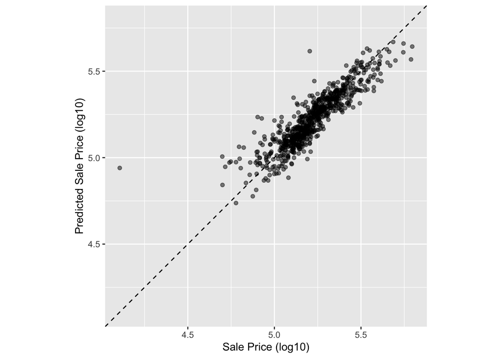

```r
ggplot(ames_test_res, aes(x = Sale_Price, y = .pred)) +
  # Create a diagonal line:
  geom_abline(lty = 2) +
  geom_point(alpha = 0.5) +
  labs(y = "Predicted Sale Price (log10)", x = "Sale Price (log10)") +
  # Scale and size the x- and y-axis uniformly:
  coord_obs_pred()
```

There is one property that is substantially over-predicted.

Let’s compute the root mean squared error for this model using the rmse() function:

```r
rmse(ames_test_res, truth = Sale_Price, estimate = .pred)
```

```
## # A tibble: 1 x 3
##   .metric .estimator .estimate
##   <chr>   <chr>          <dbl>
## 1 rmse    standard      0.0808
```

To compute multiple metrics at once, we can create a metric set. Let’s add R2 and the mean absolute error:

```r
ames_metrics <- metric_set(rmse, rsq, mae)
ames_metrics(ames_test_res, truth = Sale_Price, estimate = .pred)
```

```
## # A tibble: 3 x 3
##   .metric .estimator .estimate
##   <chr>   <chr>          <dbl>
## 1 rmse    standard      0.0808
## 2 rsq     standard      0.795
## 3 mae     standard      0.0558
```

### 9.3. Binary classification metrics

```r
data(two_class_example)
str(two_class_example)
```

```
## 'data.frame':    500 obs. of  4 variables:
##  $ truth    : Factor w/ 2 levels "Class1","Class2": 2 1 2 1 2 1 1 1 2 2 ...
##  $ Class1   : num  0.00359 0.67862 0.11089 0.73516 0.01624 ...
##  $ Class2   : num  0.996 0.321 0.889 0.265 0.984 ...
##  $ predicted: Factor w/ 2 levels "Class1","Class2": 2 1 2 1 2 1 1 1 2 2 ...
```

The second and third columns are the predicted class probabilities for the test set while predicted are the discrete predictions.

For the hard class predictions, there are a variety of yardstick functions that are helpful:

```r
# A confusion matrix:
conf_mat(two_class_example, truth = truth, estimate = predicted)
```

```
##           Truth
## Prediction Class1 Class2
##     Class1    227     50
##     Class2     31    192
```

```r
accuracy(two_class_example, truth = truth, estimate = predicted)
```

```
## # A tibble: 1 x 3
##   .metric  .estimator .estimate
##   <chr>    <chr>          <dbl>
## 1 accuracy binary         0.838
```

```r
# Matthews correlation coefficient:
mcc(two_class_example, truth, predicted)
```

```
## # A tibble: 1 x 3
##   .metric .estimator .estimate
##   <chr>   <chr>          <dbl>
## 1 mcc     binary         0.677
```

```r
# F1 metric:
f_meas(two_class_example, truth, predicted)
```

```
## # A tibble: 1 x 3
##   .metric .estimator .estimate
##   <chr>   <chr>          <dbl>
## 1 f_meas  binary         0.849
```

For binary classification data sets, these functions have a standard argument called event_level. The default is that the first level of the outcome factor is the event of interest.

There are numerous classification metrics that use the predicted probabilities as inputs rather than the hard class predictions. For example, the receiver operating characteristic (ROC) curve computes the sensitivity and specificity over a continuum of different event thresholds. The predicted class column is not used. There are two yardstick functions for this method: roc_curve() computes the data points that make up the ROC curve and roc_auc() computes the area under the curve.

```r
two_class_curve <- roc_curve(two_class_example, truth, Class1)
two_class_curve
```

```
## # A tibble: 502 x 3
##    .threshold specificity sensitivity
##         <dbl>       <dbl>       <dbl>
##  1 -Inf           0                 1
##  2    1.79e-7     0                 1
##  3    4.50e-6     0.00413           1
##  4    5.81e-6     0.00826           1
##  5    5.92e-6     0.0124            1
##  6    1.22e-5     0.0165            1
##  7    1.40e-5     0.0207            1
##  8    1.43e-5     0.0248            1
##  9    2.38e-5     0.0289            1
## 10    3.30e-5     0.0331            1
## # … with 492 more rows
```

```r
roc_auc(two_class_example, truth, Class1)
```

```
## # A tibble: 1 x 3
##   .metric .estimator .estimate
##   <chr>   <chr>          <dbl>
## 1 roc_auc binary         0.939
```

The two_class_curve object can be used in a ggplot call to visualize the curve. There is an autoplot() method that will take care of the details:

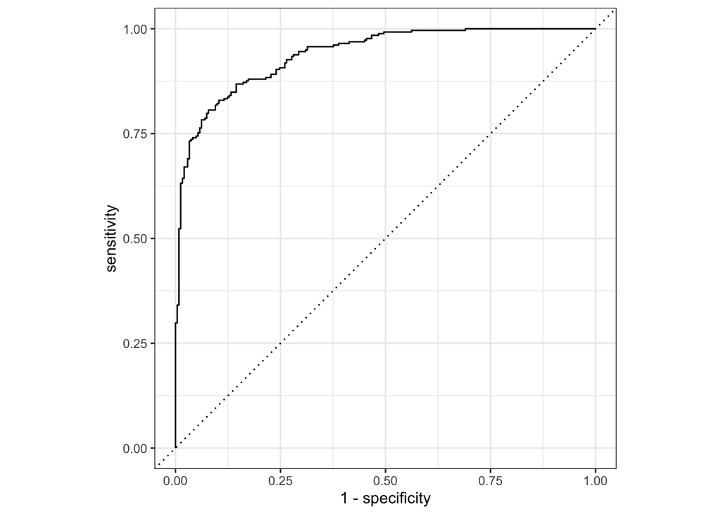

```r
autoplot(two_class_curve)
```

### 9.4. Multi-class classification metrics

```r
data(hpc_cv)
str(hpc_cv)
```

```
## 'data.frame':    3467 obs. of  7 variables:
##  $ obs     : Factor w/ 4 levels "VF","F","M","L": 1 1 1 1 1 1 1 1 1 1 ...
##  $ pred    : Factor w/ 4 levels "VF","F","M","L": 1 1 1 1 1 1 1 1 1 1 ...
##  $ VF      : num  0.914 0.938 0.947 0.929 0.942 ...
##  $ F       : num  0.0779 0.0571 0.0495 0.0653 0.0543 ...
##  $ M       : num  0.00848 0.00482 0.00316 0.00579 0.00381 ...
##  $ L       : num  1.99e-05 1.01e-05 5.00e-06 1.56e-05 7.29e-06 ...
##  $ Resample: chr  "Fold01" "Fold01" "Fold01" "Fold01" ...
```

```r
accuracy(hpc_cv, obs, pred)
```

```
## # A tibble: 1 x 3
##   .metric  .estimator .estimate
##   <chr>    <chr>          <dbl>
## 1 accuracy multiclass     0.709
```

```r
mcc(hpc_cv, obs, pred)
```

```
## # A tibble: 1 x 3
##   .metric .estimator .estimate
##   <chr>   <chr>          <dbl>
## 1 mcc     multiclass     0.515
```

## 10 Resampling for evaluating performance